#### Dragos Ailoae

2021-10-25

# Intro Regression with R

### The lm() Function and Regression Tables

Let's look back at the last homework problem:

Calculate the regression of income on GPA:

| GPA | Income |
| --- | --- |
| (Grade Point Average) | (Income of parents in $1000) |
| 4.0 | 21.0 |
| 3.0 | 15.0 |
| 3.5 | 15.0 |
| 2.0 | 9.0 |
| 3.0 | 12.0 |
| 3.5 | 18.0 |
| 2.5 | 6.0 |
| 2.5 | 12.0 |

We saw how we can calculate the parameters using the scalar (summations) and matrix forms of the OLS estimator:

### Method 1: Summations

$$ \hat\beta_0 = \frac{1}{N} \sum_{i=1}^{N} y_i - \hat\beta_1\frac{1}{N} \sum_{i=1}^{N}x_i =\bar y - \hat\beta_1 \bar x $$$$ \hat{\beta}_{1} =\frac{\frac{1}{N} \sum_{i=1}^{N}\left(x_{i}-\bar{x}\right)\left(y_{i}-\bar{y}\right)}{\frac{1}{N} \sum_{i=1}^{N}\left(x_{i}-\bar{x}\right)^{2}}=\frac{\operatorname{Cov}(x, y)}{\operatorname{Var}(x)} $$

```r
GPA <- c(4.0,3.0,3.5,2.0,3.0,3.5,2.5,2.5)
Income <- c(21.0, 15.0, 15.0, 9.0, 12.0, 18.0, 6.0, 12.0)
m1.beta.hat.1 <- cov(GPA,Income) / var(GPA)
m1.beta.hat.1
```

6.5

```r
m1.beta.hat.0 <-mean(Income) - m1.beta.hat.1 * mean(GPA)
m1.beta.hat.0
```

-6

### Method 2: Matrices

Population model in matrix form is $\mathbf{y}=\mathbf{X} \boldsymbol{\beta}+\boldsymbol{\varepsilon}$ and OLS estimator $\hat \beta = (X'X)^{-1}X'y$. In our case we have:

$$ \hat \beta =\left.\left(\begin{array}{l} \hat{\beta}_{0} \\ \hat{\beta}_{1} \end{array}\right)=\left(\left[\begin{array}{cccccccc} 1 & 1 & 1 & 1 & 1 & 1 & 1 & 1 \\ 4.0 & 3.0 & 3.5 & 2.0 & 3.0 & 3.5 & 2.5 & 2.5 \end{array}\right] \times\left[\begin{array}{ccccccc} 1 & 4.0 \\ 1 & 3.0 \\ 1 & 3.5 \\ 1 & 2.0 \\ 1 & 3.0 \\ 1 & 3.5 \\ 1 & 2.5 \\ 1 & 2.5 \end{array}\right]\right) ^{-1} \times\left[\begin{array}{cccccccc} 1 & 1 & 1 & 1 & 1 & 1 & 1 & 1 \\ 4.0 & 3.0 & 3.5 & 2.0 & 3.0 & 3.5 & 2.5 & 2.5 \end{array}\right]\left[\begin{array}{c} 21 \\ 15 \\ 15 \\ 9 \\ 12 \\ 18 \\ 6 \\ 12 \end{array}\right]\right) $$

We'll first need to add the intercept column of 1s (also known as the 'bias') to our X (or data) matrix.

```r
intercept <- rep(1, length(GPA))
intercept
```

1. 1

2. 1

3. 1

4. 1

5. 1

6. 1

7. 1

8. 1

Next we append it to our independent variable vector:

```r
X <- cbind(intercept, GPA)
X
```

A matrix: 8 × 2 of type dbl

| intercept | GPA |
| --- | --- |
| 1 | 4.0 |
| 1 | 3.0 |
| 1 | 3.5 |
| 1 | 2.0 |
| 1 | 3.0 |
| 1 | 3.5 |
| 1 | 2.5 |
| 1 | 2.5 |

Setting our dependent variable y as Income we can then calculate our betas:

```r
y <- Income
m1.betas <- solve(t(X) %*% X) %*% t(X) %*% y
m1.betas
```

A matrix: 2 × 1 of type dbl

| intercept | -6.0 |
| --- | --- |
| GPA | 6.5 |

### Method 3: The lm() function

A third option is to use prepackaged econometrics software such as R's lm() linear model fitting function:

To run a regression using the lm() function:

```r
my.lm.1 <- lm(Income ~ GPA)
my.lm.1
```

```
Call:
lm(formula = Income ~ GPA)

Coefficients:
(Intercept)          GPA
       -6.0          6.5
```

The default output is very sparse (just the coefficients) however the lm() function's output is quite rich. Here is the data structure (you can also explore this object in the RStudio Environment pane):

```r
str(my.lm.1)
```

```
List of 12
 $ coefficients : Named num [1:2] -6 6.5
  ..- attr(*, "names")= chr [1:2] "(Intercept)" "GPA"
 $ residuals    : Named num [1:8] 1 1.5 -1.75 2 -1.5 ...
  ..- attr(*, "names")= chr [1:8] "1" "2" "3" "4" ...
 $ effects      : Named num [1:8] -38.184 11.258 -1.863 0.955 -1.924 ...
  ..- attr(*, "names")= chr [1:8] "(Intercept)" "GPA" "" "" ...
 $ rank         : int 2
 $ fitted.values: Named num [1:8] 20 13.5 16.8 7 13.5 ...
  ..- attr(*, "names")= chr [1:8] "1" "2" "3" "4" ...
 $ assign       : int [1:2] 0 1
 $ qr           :List of 5
  ..$ qr   : num [1:8, 1:2] -2.828 0.354 0.354 0.354 0.354 ...
  .. ..- attr(*, "dimnames")=List of 2
  .. .. ..$ : chr [1:8] "1" "2" "3" "4" ...
  .. .. ..$ : chr [1:2] "(Intercept)" "GPA"
  .. ..- attr(*, "assign")= int [1:2] 0 1
  ..$ qraux: num [1:2] 1.35 1.15
  ..$ pivot: int [1:2] 1 2
  ..$ tol  : num 1e-07
  ..$ rank : int 2
  ..- attr(*, "class")= chr "qr"
 $ df.residual  : int 6
 $ xlevels      : Named list()
 $ call         : language lm(formula = Income ~ GPA)
 $ terms        :Classes 'terms', 'formula'  language Income ~ GPA
  .. ..- attr(*, "variables")= language list(Income, GPA)
  .. ..- attr(*, "factors")= int [1:2, 1] 0 1
  .. .. ..- attr(*, "dimnames")=List of 2
  .. .. .. ..$ : chr [1:2] "Income" "GPA"
  .. .. .. ..$ : chr "GPA"
  .. ..- attr(*, "term.labels")= chr "GPA"
  .. ..- attr(*, "order")= int 1
  .. ..- attr(*, "intercept")= int 1
  .. ..- attr(*, "response")= int 1
  .. ..- attr(*, ".Environment")=<environment: R_GlobalEnv>
  .. ..- attr(*, "predvars")= language list(Income, GPA)
  .. ..- attr(*, "dataClasses")= Named chr [1:2] "numeric" "numeric"
  .. .. ..- attr(*, "names")= chr [1:2] "Income" "GPA"
 $ model        :'data.frame':	8 obs. of  2 variables:
  ..$ Income: num [1:8] 21 15 15 9 12 18 6 12
  ..$ GPA   : num [1:8] 4 3 3.5 2 3 3.5 2.5 2.5
  ..- attr(*, "terms")=Classes 'terms', 'formula'  language Income ~ GPA
  .. .. ..- attr(*, "variables")= language list(Income, GPA)
  .. .. ..- attr(*, "factors")= int [1:2, 1] 0 1
  .. .. .. ..- attr(*, "dimnames")=List of 2
  .. .. .. .. ..$ : chr [1:2] "Income" "GPA"
  .. .. .. .. ..$ : chr "GPA"
  .. .. ..- attr(*, "term.labels")= chr "GPA"
  .. .. ..- attr(*, "order")= int 1
  .. .. ..- attr(*, "intercept")= int 1
  .. .. ..- attr(*, "response")= int 1
  .. .. ..- attr(*, ".Environment")=<environment: R_GlobalEnv>
  .. .. ..- attr(*, "predvars")= language list(Income, GPA)
  .. .. ..- attr(*, "dataClasses")= Named chr [1:2] "numeric" "numeric"
  .. .. .. ..- attr(*, "names")= chr [1:2] "Income" "GPA"
 - attr(*, "class")= chr "lm"
```

To to access just the slope coefficient:

```r
my.lm.1$coefficients[2]
```

**GPA:** 6.5

Or, to see the residuals produced by the regression:

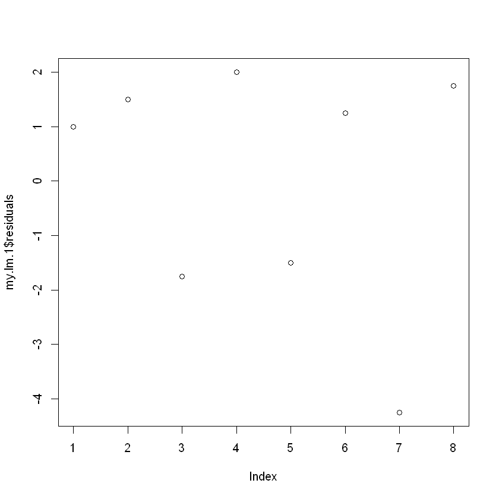

```r
plot(my.lm.1$residuals)
```

### Regression Output Tables

To view a more informative table of regression output we can use the summary() function:

```r
summary(my.lm.1)
```

```
Call:
lm(formula = Income ~ GPA)

Residuals:
   Min     1Q Median     3Q    Max
-4.250 -1.562  1.125  1.562  2.000

Coefficients:
            Estimate Std. Error t value Pr(>|t|)
(Intercept)   -6.000      4.285  -1.400  0.21095
GPA            6.500      1.399   4.645  0.00352 **
---
Signif. codes:  0 '***' 0.001 '**' 0.01 '*' 0.05 '.' 0.1 ' ' 1

Residual standard error: 2.424 on 6 degrees of freedom
Multiple R-squared:  0.7824,	Adjusted R-squared:  0.7461
F-statistic: 21.57 on 1 and 6 DF,  p-value: 0.003523
```

#### Interpreting R’s Regression Output

- Residuals: The section summarizes the residuals, the error between the prediction of the model and the actual results. Smaller residuals are better.
- Coefficients: For each variable and the intercept, a weight is produced and that weight has other attributes like the standard error, a t-test value and significance.
  - Estimate: This is the weight given to the variable.
  - Std. Error: Tells you how precisely was the estimate measured. It’s really only useful for calculating the t-value.
  - t-value and Pr(>|t|): The t-value is calculated by taking the coefficient divided by the Std. Error. It is then used to test whether or not the coefficient is significantly different from zero. If it isn’t significant, then the coefficient really isn’t adding anything to the model and could be dropped or investigated further. Pr(>|t|) is the significance level.

Performance Measures: Three sets of measurements are provided.

- Residual Standard Error: This is the standard deviation of the residuals. Smaller is better.
- Multiple / Adjusted R-Square: For one variable, the distinction doesn’t really matter. R-squared shows the amount of variance explained by the model. Adjusted R-Square takes into account the number of variables and is most useful for multiple-regression.
- F-Statistic: The F-test checks if at least one variable’s weight is significantly different than zero. This is a global test to help asses a model. If the p-value is not significant (e.g. greater than 0.05) than your model is essentially not doing anything.

Packages such as *stargazer* and *modelsummary* can produce nicely formatted tables in various formats (text, LaTeX, HTML, etc.). The output of both packages is highly customizable (see documentation) and allows users to produce ready-to-publish regression output tables. To see default outputs for these packages:

```r
options(warn=-1) # Suppress warnings
qui <- suppressPackageStartupMessages # quiet! - suppress library load messages
# install (if not already installed) and load package
qui(if(!require(stargazer)){install.packages('stargazer')})

stargazer(my.lm.1,type="text")
```

```
===============================================
                        Dependent variable:
                    ---------------------------
                              Income
-----------------------------------------------
GPA                          6.500***
                              (1.399)

Constant                      -6.000
                              (4.285)

-----------------------------------------------
Observations                     8
R2                             0.782
Adjusted R2                    0.746
Residual Std. Error       2.424 (df = 6)
F Statistic            21.574*** (df = 1; 6)
===============================================
Note:               *p<0.1; **p<0.05; ***p<0.01
```

```r
options(warn=-1) # Suppress warnings
qui <- suppressPackageStartupMessages # quiet! - suppress library load messages
# install (if not already installed) and load package
qui(if(!require(modelsummary)){install.packages('modelsummary')})

modelsummary(my.lm.1,"jupyter")         # Remove "jupyter" if running in RStudio
```

|  | Model 1 |
| --- | --- |
| (Intercept) | -6.000 |
|  | (4.285) |
| GPA | 6.500 |
|  | (1.399) |
| Num.Obs. | 8 |
| R2 | 0.782 |
| R2 Adj. | 0.746 |
| AIC | 40.6 |
| BIC | 40.8 |
| Log.Lik. | -17.284 |
| F | 21.574 |